# R Notebook

На языке Python импортируем исторические цены закрытия проводятся из пакета yfinance начиная с 2022-01-01 по текущее время. Сохраним данные в csv файл.

```
import pandas as pd
import yfinance as yf
import time

start_day = '2022-01-01'
assetList = ['BXP','C','CAG','CAH','CARR','CAT','CB', 'CBOE', 'CBRE', 'CCI']

def get_One_Asset(company,start_day):
    df = pd.DataFrame()
    returns = yf.Ticker(company)
    data = returns.history(period="1y",start=start_day)
    df.index=data.index
    df[company]=data.Close
    return df

data = pd.DataFrame()
for company in assetList:
    asset = get_One_Asset(company,start_day)
    data = pd.concat([data,asset],axis = 1)

filename = 'myData.csv'
data.to_csv(filename, index=True)
```

Подключим необходимые библиотеки.

```r
library(xts)
library(quadprog)
library(fPortfolio)
```

Считываем импортированные данные. На будущее запомним размеры датасета.

```r
data <- read.csv('myData.csv',header = TRUE)
(nAsset <- dim(data)[2])
```

```
[1] 11
```

```r
(nDays <- dim(data)[1])
```

```
[1] 592
```

Меняем тип первого столбца на `Date`.

```r
Dates <- data[,1]
Dates <- as.Date(Dates, "%Y-%m-%d")
head(Dates)
```

```
[1] "2022-01-03" "2022-01-04" "2022-01-05" "2022-01-06" "2022-01-07" "2022-01-10"
```

Убираем первый столбец c датами остальные переводим в тип xts( time series).

```r
histData <- data[2:nAsset]
sample.xts <- as.xts(histData, order.by = Dates)
head(sample.xts)
```

```
                BXP        C      CAG      CAH     CARR      CAT       CB     CBOE   CBRE      CCI
2022-01-03 105.4546 56.94045 30.79319 49.04028 50.69813 196.5581 184.6074 124.5387 108.67 186.7213
2022-01-04 108.9627 57.38262 30.91977 49.59660 51.95303 207.0793 188.6286 121.8921 110.30 181.6969
2022-01-05 107.4944 56.71486 30.87456 50.27548 50.55332 208.6650 187.0953 120.6899 106.72 169.3920
2022-01-06 109.7276 58.57377 30.31402 49.51173 51.64412 210.7920 190.9236 121.6497 105.71 173.0233
2022-01-07 110.4574 59.35884 31.41701 51.14295 50.04171 212.8810 194.0094 120.3797 104.78 175.0276
2022-01-10 110.0002 59.58444 30.89264 48.11624 50.50506 210.4597 191.7240 118.9255 103.40 171.3784
```

```r
Lag <- 5
(testData <- sample.xts[(nDays-Lag):nDays,])
```

```
             BXP     C   CAG   CAH  CARR    CAT     CB   CBOE  CBRE   CCI
2024-05-03 60.78 61.52 30.59 98.91 62.09 336.75 248.54 179.67 86.61 97.39
2024-05-06 61.59 62.81 30.19 98.59 64.06 342.10 252.05 182.87 86.32 95.92
2024-05-07 60.86 62.00 30.72 99.72 64.26 345.00 251.95 184.25 86.51 96.15
2024-05-08 60.12 62.75 30.83 97.44 64.31 344.50 251.63 185.50 86.50 97.31
2024-05-09 61.43 63.32 30.78 98.06 65.24 351.78 254.04 182.92 87.44 99.88
2024-05-10 61.50 63.53 31.13 99.53 65.50 354.79 254.84 181.06 90.22 99.51
```

```r
sample.xts <- sample.xts[1:(nDays-Lag),]
(nDays <- nDays - Lag)
```

```
[1] 587
```

Нормируем данные и изобразим их на графике.

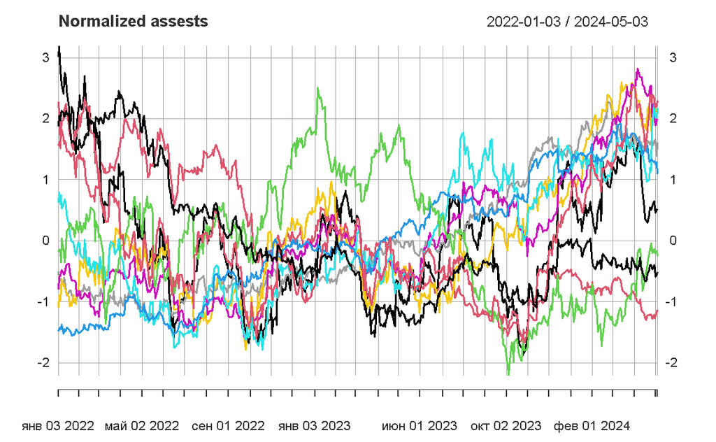

```r
std_data <- scale(sample.xts)
plot(std_data,lty=1,main='Normalized assests',type = "l")
```

Переходим к рядам из геометрических доходностей. Уберем в них первую строку.

```r
stock.returns <- returns(sample.xts,method = 'discrete')
head(stock.returns)
```

[output not shown]

```r
stock.returns <- stock.returns[2:nDays,]
print('_________________________________________________________________________________________________')
```

```
[1] "_________________________________________________________________________________________________"
```

```r
head(stock.returns)
```

```
                    BXP            C          CAG         CAH         CARR          CAT           CB
2022-01-04  0.033266549  0.007765467  0.004110502  0.01134407  0.024752355  0.053526750  0.021782162
2022-01-05 -0.013475393 -0.011637087 -0.001462106  0.01368817 -0.026941722  0.007657644 -0.008128321
2022-01-06  0.020775467  0.032776549 -0.018155500 -0.01519134  0.021577242  0.010193513  0.020461722
2022-01-07  0.006650643  0.013403007  0.036385515  0.03294617 -0.031027987  0.009910264  0.016162484
2022-01-10 -0.004139145  0.003800634 -0.016690708 -0.05918146  0.009259244 -0.011374151 -0.011779842
2022-01-11 -0.013108388  0.016356329 -0.005560228  0.03292194  0.004204886 -0.007625128  0.003319505
                   CBOE         CBRE         CCI
2022-01-04 -0.021251759  0.014999585 -0.02690862
2022-01-05 -0.009862400 -0.032456951 -0.06772204
2022-01-06  0.007952553 -0.009464038  0.02143682
2022-01-07 -0.010440096 -0.008797657  0.01158454
2022-01-10 -0.012080244 -0.013170426 -0.02084937
2022-01-11  0.026656873  0.018181791 -0.01615365
```

Изобразим геометрические доходности на графике.

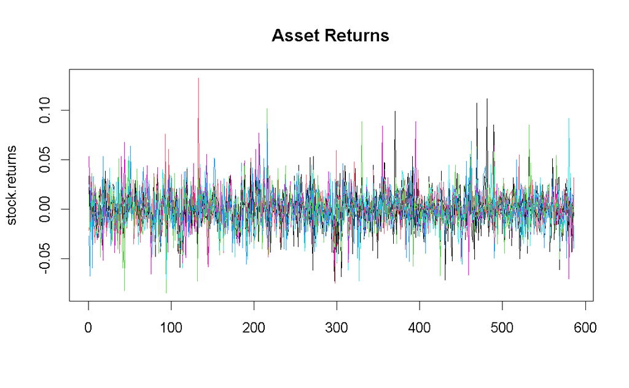

```r
matplot(stock.returns,lty=1,main='Asset Returns',type = "l")
```

Считаем ковариационную матрицу доходностей.

```r
(cov <- cov(stock.returns))
```

```
              BXP            C          CAG          CAH         CARR          CAT           CB
BXP  5.403265e-04 2.097427e-04 7.250207e-05 5.149367e-05 2.065828e-04 1.923226e-04 8.109856e-05
C    2.097427e-04 3.264151e-04 6.540966e-05 6.941496e-05 1.705642e-04 1.740527e-04 9.599653e-05
CAG  7.250207e-05 6.540966e-05 1.913124e-04 6.250377e-05 3.999901e-05 3.739102e-05 5.535021e-05
CAH  5.149367e-05 6.941496e-05 6.250377e-05 2.296905e-04 5.521216e-05 7.036153e-05 7.890869e-05
CARR 2.065828e-04 1.705642e-04 3.999901e-05 5.521216e-05 3.941057e-04 1.819889e-04 1.028929e-04
CAT  1.923226e-04 1.740527e-04 3.739102e-05 7.036153e-05 1.819889e-04 3.678780e-04 9.394241e-05
CB   8.109856e-05 9.599653e-05 5.535021e-05 7.890869e-05 1.028929e-04 9.394241e-05 1.700712e-04
CBOE 2.632206e-05 3.771021e-05 3.889797e-05 5.886913e-05 5.599205e-05 2.681159e-05 6.031928e-05
CBRE 2.912073e-04 2.073288e-04 6.037798e-05 6.698717e-05 2.254274e-04 1.622550e-04 8.933884e-05
CCI  2.165277e-04 1.188051e-04 6.750304e-05 3.997216e-05 1.374813e-04 8.873274e-05 5.358230e-05
             CBOE         CBRE          CCI
BXP  2.632206e-05 2.912073e-04 2.165277e-04
C    3.771021e-05 2.073288e-04 1.188051e-04
CAG  3.889797e-05 6.037798e-05 6.750304e-05
CAH  5.886913e-05 6.698717e-05 3.997216e-05
CARR 5.599205e-05 2.254274e-04 1.374813e-04
CAT  2.681159e-05 1.622550e-04 8.873274e-05
CB   6.031928e-05 8.933884e-05 5.358230e-05
CBOE 1.868227e-04 5.849572e-05 4.781319e-05
CBRE 5.849572e-05 3.788854e-04 1.786188e-04
CCI  4.781319e-05 1.786188e-04 3.197391e-04
```

Зададим матрицу `Amat` и вектор `bvec` ограничений.

```r
n <- ncol(cov)
Amat <- matrix (1, nrow=n)
Amat <- cbind(Amat, -diag(n))
meq <- 1
bvec <- 1
```

Зададим ограничение.

```r
max.allocation <- 0.45
bvec <- c(bvec, rep(-max.allocation, n))
bvec
```

```
 [1]  1.00 -0.45 -0.45 -0.45 -0.45 -0.45 -0.45 -0.45 -0.45 -0.45 -0.45
```

Зададим максимальную доходность и шаг изменения доходности и определим количество итераций цикла по доходности.

```r
risk.premium.up <-0.5
risk.increment <- 0.01
(loops <- risk.premium.up / risk.increment + 1)
```

```
[1] 51
```

Инициализируем матрицу, где будем хранить оптимальные портфели и различные статистики и заполним ее.

```r
eff <- matrix(nrow=loops, ncol=n+3)
colnames(eff) <- c(colnames(stock.returns), "Std.Dev", "Exp.Return", "sharpe")

mu <- colMeans(stock.returns)

loop <- 1

for (i in seq(from=0, to=risk.premium.up, by=risk.increment)){
    dvec <- mu * i
    sol <- solve.QP(cov, dvec=dvec, Amat=Amat, bvec=bvec, meq=meq)
    eff[loop,"Std.Dev"] <- sqrt(sum(sol$solution *colSums((cov * sol$solution))))
    eff[loop,"Exp.Return"] <- as.numeric(sol$solution %*% colMeans(stock.returns))
    eff[loop,"sharpe"] <- eff[loop,"Exp.Return"] / eff[loop,"Std.Dev"]
    eff[loop,1:n] <- sol$solution
    loop <- loop+1
}
eff <- as.data.frame(eff)
head(eff)
```

|  | BXP | C | CAG | CAH | CARR | CAT | CB | CBOE | CBRE | CCI | Std.Dev | Exp.Return | sharpe |
| --- | --- | --- | --- | --- | --- | --- | --- | --- | --- | --- | --- | --- | --- |
| 1 | 0.0002707952 | 0.02994815 | 0.2356516 | 0.1254854 | 0.01990595 | 0.08093365 | 0.1742448 | 0.2627146 | -0.03258047 | 0.10342553 | 0.009143592 | 0.0004935862 | 0.05398165 |
| 2 | -0.0129132470 | 0.02989975 | 0.2165420 | 0.1684392 | 0.03425097 | 0.10863433 | 0.1638041 | 0.2774022 | -0.04400922 | 0.05794990 | 0.009226220 | 0.0006453732 | 0.06994991 |
| 3 | -0.0260972892 | 0.02985136 | 0.1974325 | 0.2113930 | 0.04859600 | 0.13633502 | 0.1533634 | 0.2920897 | -0.05543797 | 0.01247428 | 0.009469781 | 0.0007971603 | 0.08417938 |
| 4 | -0.0392813314 | 0.02980296 | 0.1783230 | 0.2543468 | 0.06294102 | 0.16403571 | 0.1429227 | 0.3067772 | -0.06686672 | -0.03300135 | 0.009862358 | 0.0009489474 | 0.09621912 |
| 5 | -0.0524653736 | 0.02975457 | 0.1592135 | 0.2973006 | 0.07728604 | 0.19173640 | 0.1324820 | 0.3214648 | -0.07829547 | -0.07847698 | 0.010387069 | 0.0011007344 | 0.10597161 |
| 6 | -0.0656494158 | 0.02970617 | 0.1401039 | 0.3402544 | 0.09163107 | 0.21943709 | 0.1220413 | 0.3361523 | -0.08972422 | -0.12395261 | 0.011025064 | 0.0012525215 | 0.11360674 |

Определяем точку, где коэффициент Шарпа максимален.

```r
eff.optimal.point <- eff[eff$sharpe==max(eff$sharpe),]

plot(eff$Std.Dev,eff$Exp.Return,type = 'b',pch =21,col = 'green',lwd = 2)
points(eff.optimal.point$Std.Dev,eff.optimal.point$Exp.Return,pch = 20,col = 'red',lwd = 4)
```

```r
text(eff.optimal.point$Std.Dev,eff.optimal.point$Exp.Return-0.0005,paste('Sharpe',round(eff.optimal.point$sharpe,3)))
text(eff.optimal.point$Std.Dev,eff.optimal.point$Exp.Return-0.0008,paste('Std.Dev',round(eff.optimal.point$Std.Dev,3)))
```

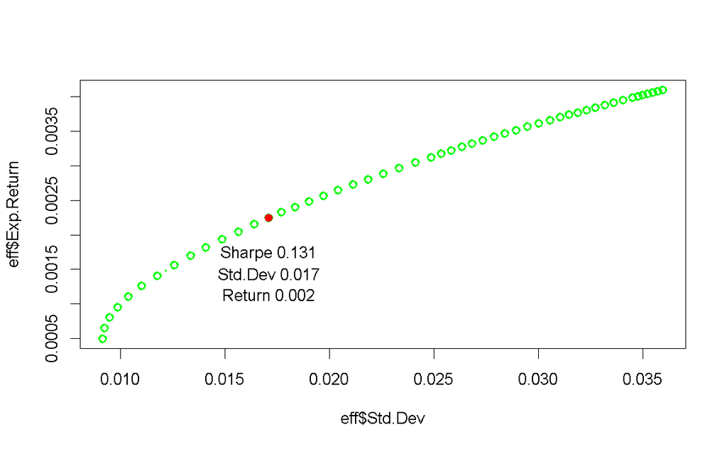

```r
text(eff.optimal.point$Std.Dev,eff.optimal.point$Exp.Return-0.0011,paste('Return',round(eff.optimal.point$Exp.Return,3)))
```

Оптимальный портфель по Марковитцу.

```r
eff.optimal.point
```

|  | BXP | C | CAG | CAH | CARR | CAT | CB | CBOE | CBRE | CCI | Std.Dev | Exp.Return | sharpe |
| --- | --- | --- | --- | --- | --- | --- | --- | --- | --- | --- | --- | --- | --- |
| 14 | -0.1832547 | 0.04516252 | 0.06584137 | 0.45 | 0.2052371 | 0.45 | 0.1558929 | 0.45 | -0.1638564 | -0.4750228 | 0.01708642 | 0.002239961 | 0.131096 |

Предположим у нас 1000000 долларов. Разделим их на доли вложения в каждый актив. Для этого нормируем оптимальный портфель так, чтобы сумма модулей была равна 1. Проверим, что наша нормализация сработала.

```r
eff.optimal.point<-eff.optimal.point[1:nAsset - 1]
sabs <- sum(abs(eff.optimal.point))
norm_eff.optimal.point <- eff.optimal.point/sabs
sum(abs(norm_eff.optimal.point))
```

```
[1] 1
```

Поделим весь капитал на долю вложения на каждый актив.

```r
N <- 1000000
(d_money <- norm_eff.optimal.point*N)
```

|  | BXP | C | CAG | CAH | CARR | CAT | CB | CBOE | CBRE | CCI |
| --- | --- | --- | --- | --- | --- | --- | --- | --- | --- | --- |
| 14 | -69302.63 | 17079.41 | 24899.66 | 170179.4 | 77615.86 | 170179.4 | 58955.04 | 170179.4 | -61966.65 | -179642.5 |

В итоге посмотрим на портфель на следующий интервал времени в количестве акций на последний день тренировочной выборки.

```r
nData <- dim(sample.xts)[1]
(portfolio <- as.integer (d_money / histData[nData,]))
```

```
 [1] -1140   277   813  1720  1250   505   237   947  -715 -1844
```

Вычислим стоимость портфеля на момент создания с учетом округлений.

```r
sum(abs(portfolio)*histData[nData,])
```

```
[1] 999561.1
```

Посмотрим на стоимость нашего портфеля по тестовым 5 дням.

```r
res <- rep(0,Lag)
for (i in 1 : Lag)
{
  change <- histData[nData+i,]-histData[nData,]
  res[i]<-sum(portfolio*change)
  print(paste(Dates[nData+i],' ',res[i]))
}
```

```
[1] "2024-05-06   10502.8685703278"
[1] "2024-05-07   15922.8829555511"
[1] "2024-05-08   11928.0924663544"
[1] "2024-05-09   9173.94713783264"
[1] "2024-05-10   10933.0777072906"
```

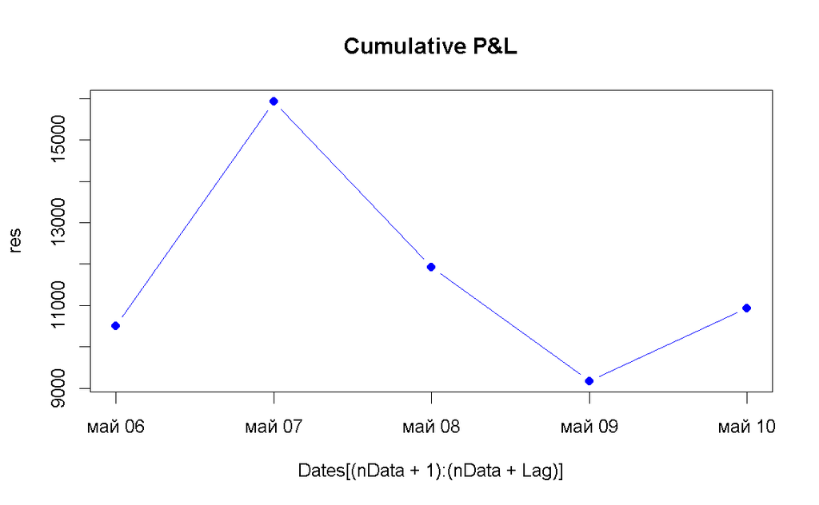

```r
plot(Dates[(nData+1):(nData+Lag)], res,main='Cumulative P&L',type="b",col = 'blue',pch=16)
```